# Week 10 and 11

Penelope Pooler Eisenbies

2024-03-28

```r
# this line specifies options for default options for all R Chunks
knitr::opts_chunk$set(echo=T,
                      highlight=T)

# suppress scientific notation
options(scipen=100,
        getSymbols.warning4.0 = FALSE)

# install helper package (pacman), if needed
if (!require("pacman")) install.packages("pacman", repos = "http://lib.stat.cmu.edu/R/CRAN/")
```

```r
# install and load required packages
# pacman should be first package in parentheses and then list others
pacman::p_load(pacman,tidyverse, ggthemes, magrittr, knitr, lubridate, gridExtra, RColorBrewer,
               flexdashboard, maps, usdata, countrycode, mapproj, shadowtext, grid)

# verify packages (comment out in finished documents)
p_loaded()
```

```
##  [1] "shadowtext"    "mapproj"       "countrycode"   "usdata"
##  [5] "maps"          "flexdashboard" "RColorBrewer"  "gridExtra"
##  [9] "knitr"         "magrittr"      "ggthemes"      "lubridate"
## [13] "forcats"       "stringr"       "dplyr"         "purrr"
## [17] "readr"         "tidyr"         "tibble"        "ggplot2"
## [21] "tidyverse"     "pacman"
```

### Today and Tuesday

- **Practice Questions and Demo Videos for Quiz 2 are available.**
- Tue. 4/2: Skills/Concepts Review for Quiz 2
  - Putting skills together for different goals
  - Come with questions or submit them in Engagement Questions
- Today - Intro to Managing and Plotting Geographic Data
  - Today’s geographic maps will not be on Quiz 2.
  - Mapping data is an effective data curation tool that may be useful in this class, other classes, your career.
- We will cover more about geographic data and map visualizations after Quiz 2.
- **If you want help with mapping project data, please reach out to me or TAs**.

### In-class Exercise 1 - Week 10

**Purpose:**

- To gain some experience and understanding of map data available in R and elsewhere.
- To experiment with mapping data
- Students are encouraged to use domestic or international map data in their dashboards if appropriate.

### Plots by US County

#### Data Preparation

- The data for today’s in-class exercise is part of R.
- These geographic data are useful if you have information by state or county and you want to show a [choropleth map](https://en.wikipedia.org/wiki/Choropleth_map) of your data.
- R also has world information, e.g., countries, continents, etc.

```r
us_states <- map_data("state") |>                    # state polygons (not used today)
  rename("state" = "region")

us_counties <- map_data("county") |>                 # county polygons
  rename("state" = "region", "county" = "subregion")
# unique(us_counties$county[us_counties$state=="louisiana"])   # note issue Louisiana counties

cnty2019_all <- county_2019
# unique(cnty2019_all$county[cnty2019_all$state=="louisiana"]) # note issue Louisiana counties

cnty2019_all <- cnty2019_all |>
  mutate(state = tolower(state),
         county = tolower(name),
         county = gsub(" county", "", county),
         county = gsub(" parish", "", county),
         county = gsub("\\.", "", county))            # \\ is required because . used in R coding

cnty2019_all <- full_join(us_counties,cnty2019_all)  # geo data and demographic data
```

### County Demographic Plots

- Creating a new dataset not required, but helpful
- Plot code could be converted into a function

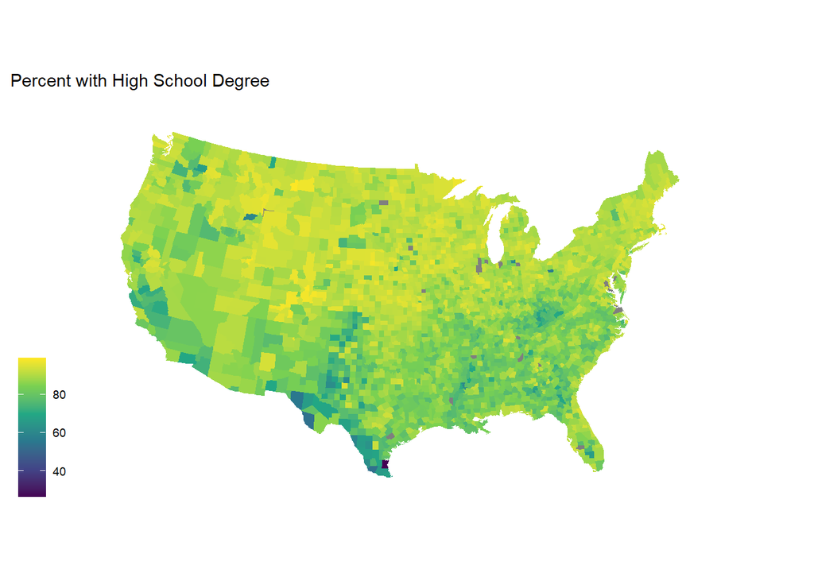

```r
# select data
cnty_data1 <- cnty2019_all |>
  select(long:county, hs_grad, bachelors,
         household_has_computer,
         household_has_broadband)


# hs grad pct plot
(cnty_hs_grad <- cnty_data1 |>
  ggplot(aes(x=long, y=lat,
             group=group, fill=hs_grad)) +
    geom_polygon() +
    theme_map() +
    coord_map("albers", lat0 = 39, lat1 = 45) +
    labs(fill= "",
         title="Percent with High School Degree") +
    scale_fill_continuous(type = "viridis"))
```

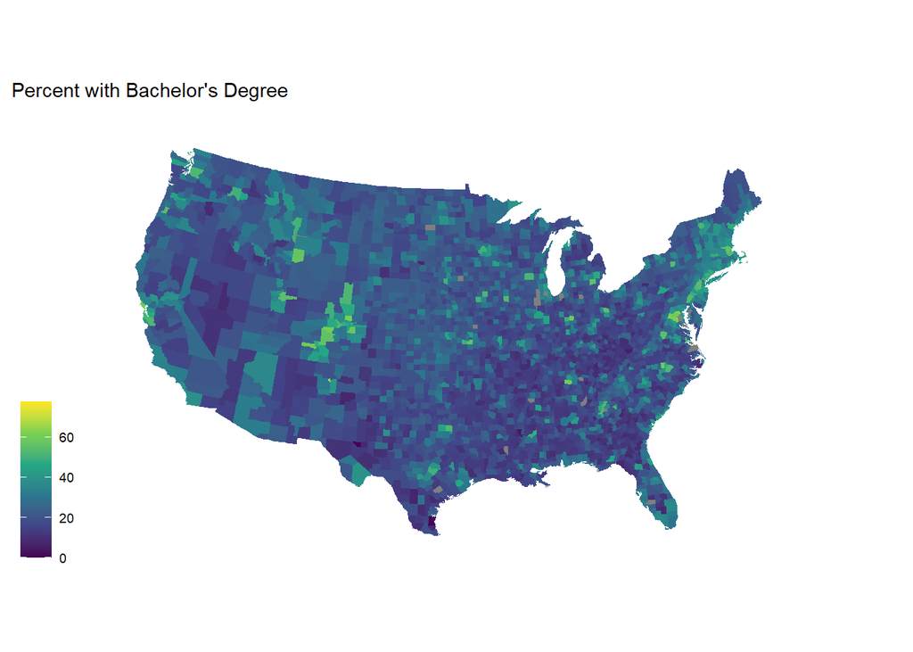

```r
# bachelors pct plot
(cnty_bachelors <- cnty_data1 |>
  ggplot(aes(x=long, y=lat,
             group=group,
             fill=bachelors)) +
    geom_polygon() +
    theme_map() +
    coord_map("albers", lat0 = 39, lat1 = 45) +
    labs(fill= "", title="Percent with Bachelor's Degree") +
    scale_fill_continuous(type = "viridis"))
```

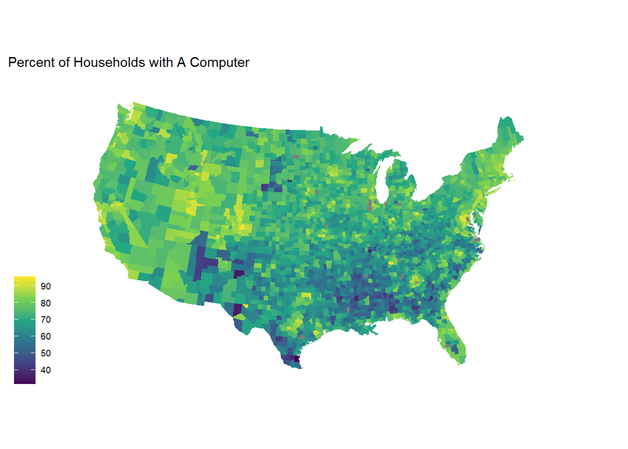

```r
# hh has computer pct plot
(cnty_computer <- cnty_data1 |>
  ggplot(aes(x=long, y=lat,
             group=group,
             fill=household_has_computer)) +
    geom_polygon() +
    theme_map() +
    coord_map("albers", lat0 = 39, lat1 = 45) +
    labs(fill= "", title="Percent of Households with A Computer")+
    scale_fill_continuous(type = "viridis"))
```

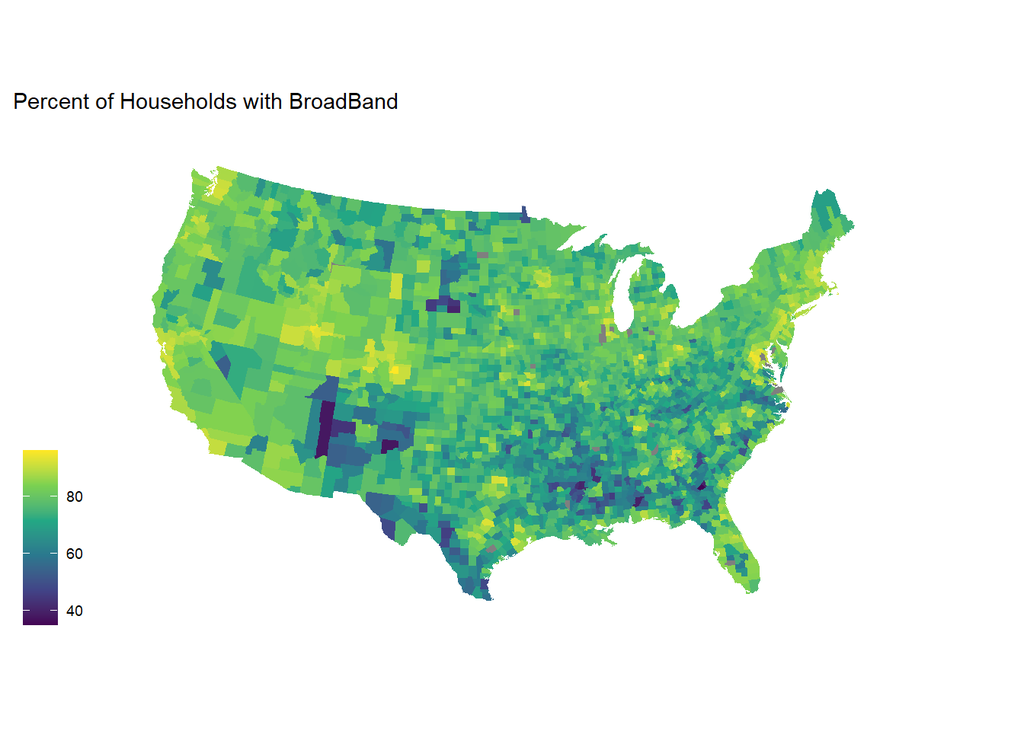

```r
# hh has broadband pct plot
(cnty_brdbd <- cnty_data1 |>
  ggplot(aes(x=long, y=lat,
             group=group,
             fill=household_has_broadband)) +
    geom_polygon() +
    theme_map() +
    coord_map("albers", lat0 = 39, lat1 = 45) +
    labs(fill= "", title="Percent of Households with BroadBand") +
    scale_fill_continuous(type = "viridis"))
```

### Demographic Plot Grid - Order Matters - L to R by Rows

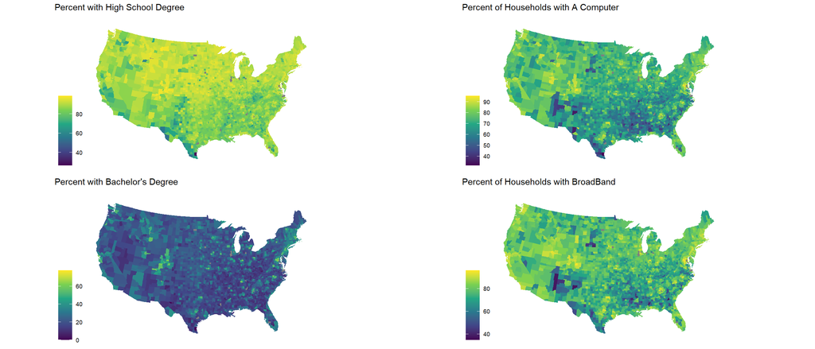

### In-class Exercise 1 - 2x2 Plot Grid - Steps 1 and 2

**Steps to Follow**

**`1.`** Examine the available variables in the **`cnty_2019_all`** dataset saved from R.

**`2.`** Create Individual Plots**.

- Variable names in R dataset and definitions:
  - **`household_has_smartphone`: Households with Smart Phones**
  - **`median_age`: Median Age**
  - **`median_household_income`: Median Household Income**
  - **`median_individual_income`: Median Individual Income**

#### Create Individual Plots

You can copy provided plot code and modify it for these variables or you can try to create a function (not required today).

```r
# select data for plot (not required, but helpful)
# cnty_data2 <-

# create four individual plots, one for each variable
# use provided plot code and modify
```

### In-class Exercise 1 - 2x2 Plot Grid - Steps 3 and 4

**`3.`** Create 2x2 plot grid of these four variables by US County as part of your class participation credit for this week.

- **For full credit, plots must be in the order specified.**
  - **Row 1:** should have smartphone variable and median age.
  - **Row 2:** median household and individual income.

#### Create Plot Grid using `grid.arrange`

```r
# for full credit grid of plots must be in order specified
# border around all four plots not required
```

**`4.`** Two Options to Export and Submit plot grid

1. Right click on plot grid, then save as…
2. Use R code below but modify for your filename (height and width can also be modified)
   - Use your completed `grid.arrange` command from your plots

```r
grid.arrange(cnty_hs_grad, cnty_computer, cnty_bachelors, cnty_brdbd, ncol=2)
ggsave("Wk10_Example_Plot_Grid_Penelope_Pooler.png", height=4, width=6)
```

### Plot of Skewed Data

**If map looks like this, examine histogram of data.**

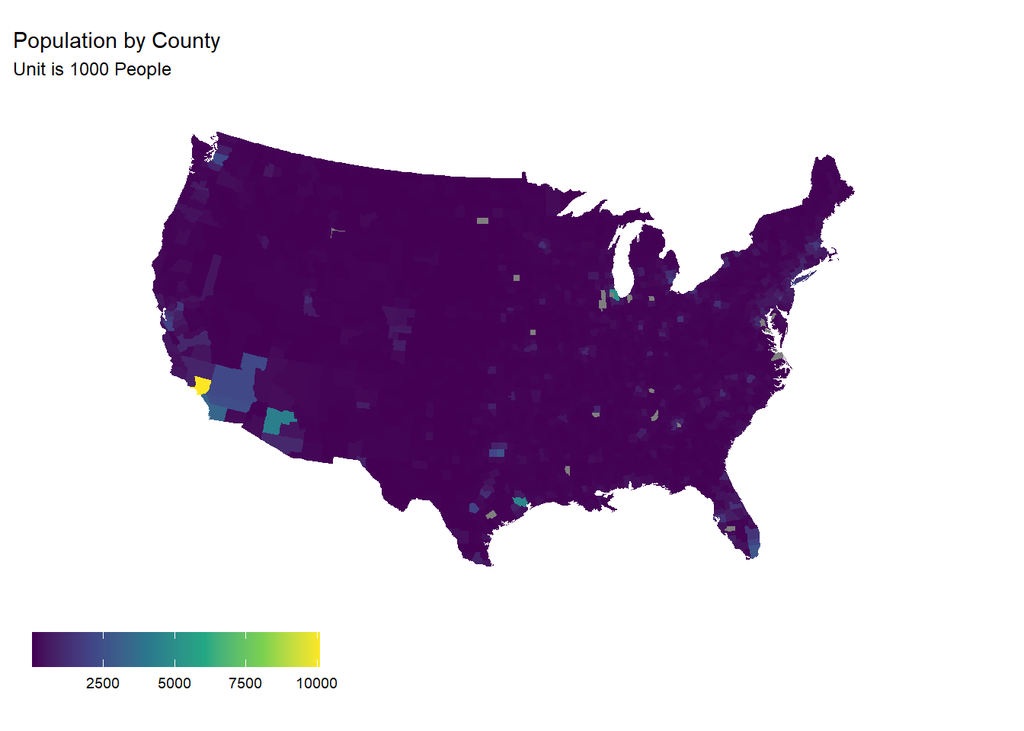

```r
cnty_data3 <- cnty2019_all |>
  select(long:county, pop) |>
  mutate(pop1k = pop/1000)

(cnty_pop <- cnty_data3 |>
    ggplot(aes(x=long, y=lat, group=group, fill=pop1k)) +
    geom_polygon() +
    theme_map() +
    coord_map("albers", lat0 = 39, lat1 = 45) +
    labs(fill= "", title="Population by County",
         subtitle="Unit is 1000 People") +
    scale_fill_continuous(type = "viridis") +
    theme(legend.position = "bottom",
          legend.key.width = unit(1, "cm")))
```

### Histogram Clarifies Data Skewness

**Histogram confirms highly right-skewed data.**

**The Problem:** We see we have skewed data BUT presenting log transformed data in a map makes it difficult to interpret.

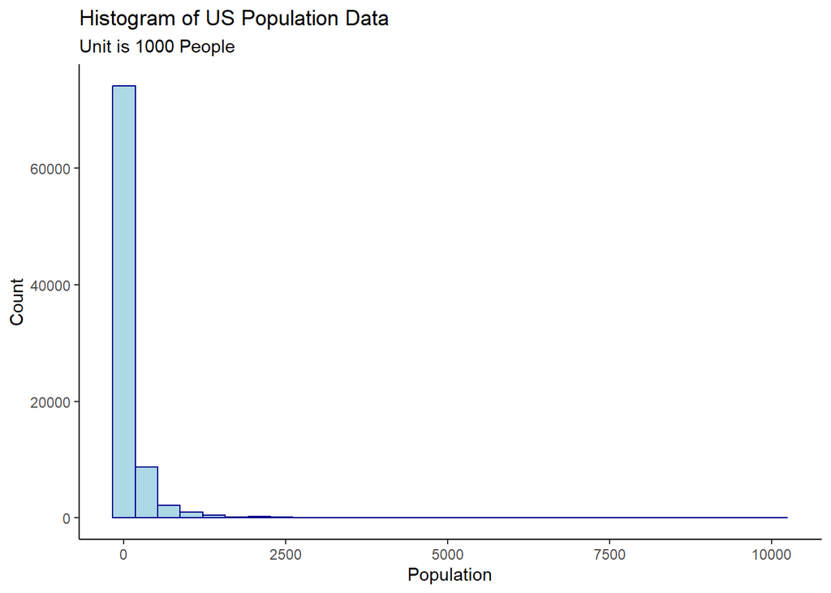

```r
(hist_pop <- cnty_data3 |>
  ggplot() +
  geom_histogram(aes(x=pop1k),
                 fill="lightblue",
                 col="darkblue") +
  labs(x="Population", title="Histogram of US Population Data",
       y = "Count",subtitle="Unit is 1000 People") +
  theme_classic())
```

### Solution - Skewed Variable shown using Natural Log Transfomed Axis

- Data are not transformed, but data axes and scale are
- Options specified in `scale_fill_continuous`:
  - `trans = "log"`
  - `breaks = c(...)`
- break intervals determined by examining data

**Transformed Data shown on log scale (see legend intervals)**

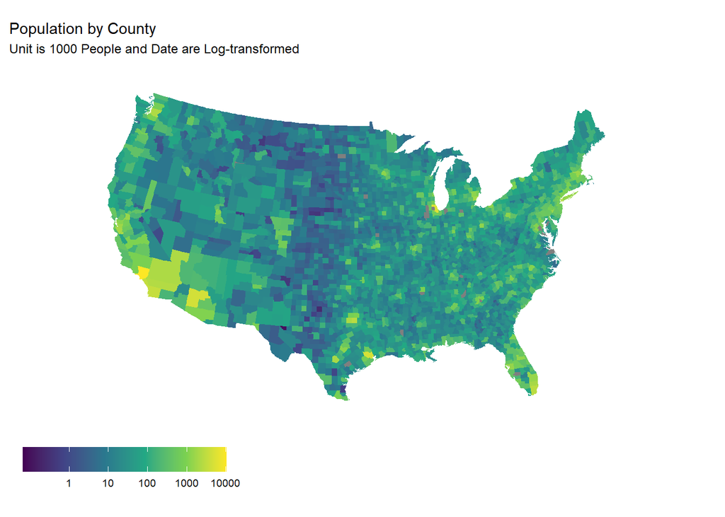

```r
(cnty_lpop <- cnty_data3 |>
  ggplot(aes(x=long, y=lat, group=group, fill=pop1k)) +
    geom_polygon() +
    theme_map() +
    coord_map("albers", lat0 = 39, lat1 = 45) +
    labs(fill= "", title="Population by County",
         subtitle="Unit is 1000 People and Date are Log-transformed") +
    scale_fill_continuous(type = "viridis",trans="log",
                          breaks=c(1,10,100,1000,10000)) +
    theme(legend.position = "bottom",
          legend.key.width = unit(1, "cm")))
```

### Histogram of Log transformed Data

- In a final dashboard, usually don’t show histograms
- Ideal for exploring the data.
- Scatterplots and boxplots are also useful for data exploration.

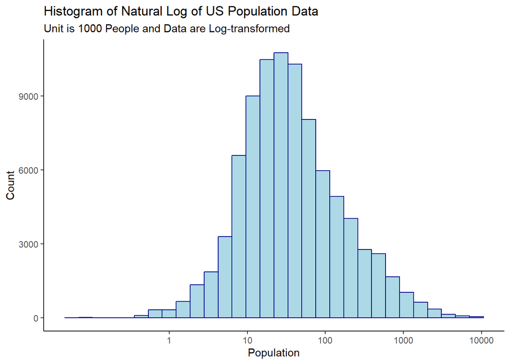

```r
(hist_lpop <- cnty_data3 |>
  ggplot() +
  geom_histogram(aes(x=pop1k),fill="lightblue", col="darkblue") +
  labs(x="Population",
       title="Histogram of Natural Log of US Population Data",
       y = "Count",
       subtitle="Unit is 1000 People and Data are Log-transformed") +
  theme_classic() +
  scale_x_continuous(trans="log", breaks=c(1,10,100,1000,10000)))
```

### Population Plot Grid

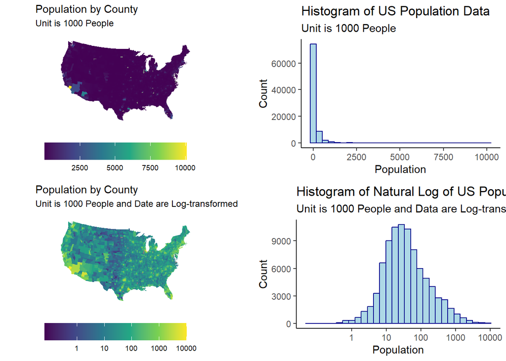

```r
grid.arrange(cnty_pop, hist_pop, cnty_lpop, hist_lpop, ncol=2)
```

### When and How to Log Transform

- Log transformation are useful if you have right skewed POSITIVE data such as
  - Prices
  - Population
  - Sales
  - Income
- Note: If data (x) have zeros, a good option is to use log(x + 1)
  - ln(1) = 0 (In R `log(1)` = 0)
  - 0 values in the data will still be zeros
- In the following example we will create plots for number of households by county:
  - Histograms with and without LN transformation
  - Map plots of with and without LN transformation

### Number of Households Per County

#### Untransformed Data Histogram

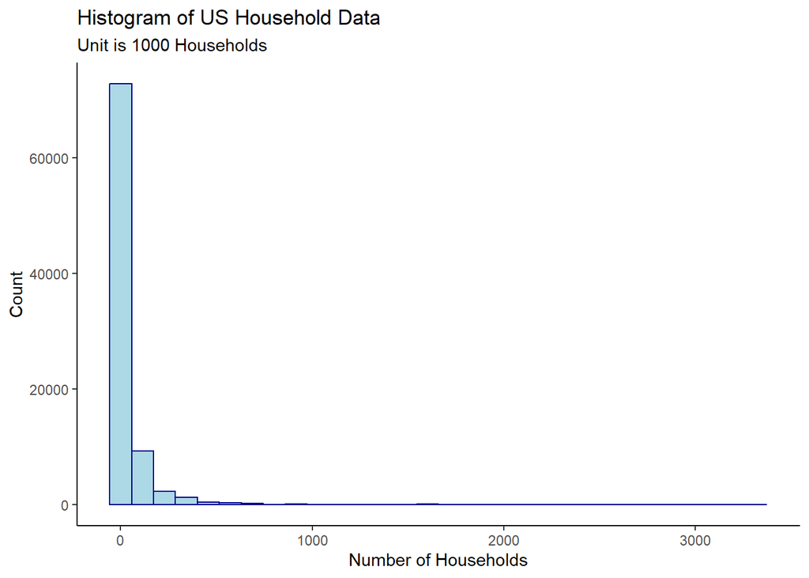

```r
cnty_data4 <- cnty2019_all |>
  select(long:county, households) |>
  mutate(households1K = households/1000)

(hist_hholds <- cnty_data4 |>
  ggplot() +
  geom_histogram(aes(x=households1K),
                 fill="lightblue",
                 col="darkblue") +
  labs(x="Number of Households", title="Histogram of US Household Data",
       y = "Count",subtitle="Unit is 1000 Households") +
  theme_classic())
```

### Number of Households Per County

#### Log transformed Data Histogram

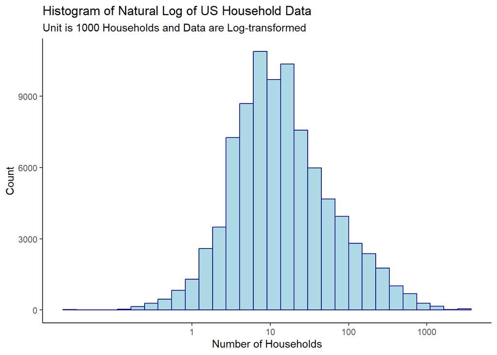

```r
(hist_lhholds <- cnty_data4 |>
  ggplot() +
  geom_histogram(aes(x=households1K),
                 fill="lightblue",
                 col="darkblue") +
  labs(x="Number of Households",
       title="Histogram of Natural Log of US Household Data",
       y = "Count",
       subtitle="Unit is 1000 Households and Data are Log-transformed") +
  theme_classic() +
  scale_x_continuous(trans="log", breaks=c(1,10,100,1000)))
```

### Number of Households Per County

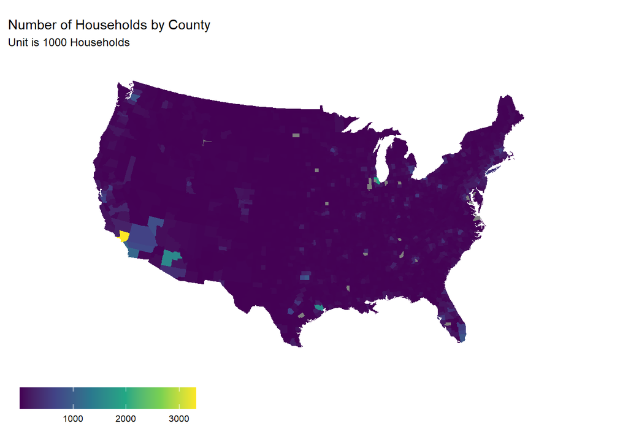

```r
(cnty_hholds <- cnty_data4 |>
  ggplot(aes(x=long, y=lat, group=group, fill=households1K)) +
  geom_polygon() +
  theme_map() +
  coord_map("albers", lat0 = 39, lat1 = 45) +
  labs(fill= "", title="Number of Households by County",
       subtitle="Unit is 1000 Households") +
  scale_fill_continuous(type = "viridis") +
  theme(legend.position = "bottom",
        legend.key.width = unit(1, "cm")))
```

**Log-transformed data map is more more informative about geographic variability.**

#### In-class Exercise 2: Submit R code to create log transformed households map in a text file with your name.**

```r
# cnty_lhholds <- cnty_data4 |>
```

### Households per County Plot Grid

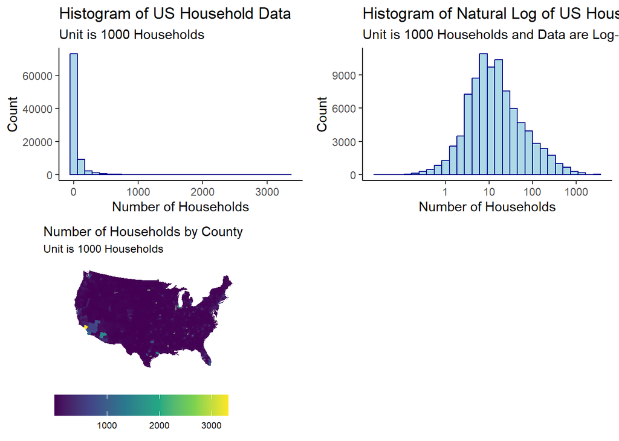

```r
grid.arrange(hist_hholds, hist_lhholds, cnty_hholds, ncol=2)
```

### Additional Text Commands (Not on Quiz 2)

- New commands (not for quiz): Capitalize 1st letter
- [Commands to covert case](https://stringr.tidyverse.org/reference/case.html)
- `str_to_title`: First letter of each word
- `str_to_sentence`: First letter of first word

### Additional skills for Quiz 2 from HW 5 - Part 1

- summing across rows using `sum(c_across(...))`
- using `pivot_wider` and then `pivot_longer` and then replacing NAs with 0 to create a ‘complete’ data set
  - Useful for area plots
- Plotting skills for Quiz 2
  - line plot or area plot
  - `hchart` in **highcharter** package
  - possibly a grouped bar chart

### **Key Points from Week 10 and 11**

**Introduction to Geographic Data**

- Use skills already covered to
  - clean data and check text variables
  - join datasets
  - create plot grids for comparing variables
- Determine if variables need to be log-transformed.
- Quiz 2 Practice Questions are available.
- Quiz 2 will be on Thursday, 4/4.

You may submit an ‘Engagement Question’ about each lecture until midnight on the day of the lecture. **A minimum of four submissions are required during the semester.**